# Projekt 1 etap 1

Adrianna Wlazło, Patrycja Faszczewska

2 listopada 2016

Wczytujemy dane z pliku cancer.rda, które są już oczyszczone, tj. atrybuty, które mają ponad 10 wartościi pustych zostały usunięte (921 kolumn-genów pozbyliśmy się na tym etapie), natomiast w przypadku mniejszych braków na nieokreślone wartości przypisałyśmy wartości średnie (aby unknąć kłopotów w trakcie przeprowadzania testów korelacji).

Dane odnośnie przeżycia pacjentów w pierwszym roku po leczeniu przypisaliśmy do zmiennej zero-jedynkowej (wektor d). W przypadku śmierci przypisałyśmy wartość jeden, natomiast przeżycia wartośc 0.

Zdecydowałyśmy się na zbadanie istotności zmiennych objaśniających za pomocą testu korelacji metodą Spearmana, gdyż bada on monotoniczną zależność między zmiennymi. Test ten wykonałyśmy wielokrotnie, dla par zmiennych - zmiennej objaśnianej oraz każdej ze zmiennych objaśniających. W pierwszym momencie test wykonałyśmy na wszystkich dostępnych obserwacjach. W następnym kroku natomiast zajmiemy się podziałem zbioru na testowy i uczący oraz przeprowadzimy powyższą procedure ponownie.

W celu przeprowadzania dalszych analiz w trakcie wykonywania testów na wektor p przypisujemy p-wartości otrzymane w kolejnych testach, natomiast na wektor r- wartości współczynniki korelacji.

```r
d <- as.numeric(ifelse(cancer$death1y=='dead',1,0))

p<-apply(data.matrix(cancer[,-c(1,2,4)]),2,function(x)cor.test(d,x,method="spearman")$p.value)
r<-apply(data.matrix(cancer[,-c(1,2,4)]),2,function(x)cor.test(d,x,method="spearman")$estimate)
```

Test korelacji zakłada hipotezę zerową mówiącą o niezależności badanych zmiennych. Tak więc dla p-wartości poniżej ustalonego poziomu istotności będziemy skłonni przyjąć, że odpowiadająca jej zmienna zależy od śmiertelności pacjentów w pierwszym roku po leczeniu.

Przedstawimy histogram otrzymanych p-wartości aby sprawdzić jak dużo z wyestymowanych wartości należy do wspomnianego wyżej przedziału oraz zbadać ich rozkład. Zgodnie z teorią w przypadku, gdy hipoteza zerowa jest prawdziwa p-wartości powinny mieć rozkład jednostajny, co postaramy sie zweryfikować.

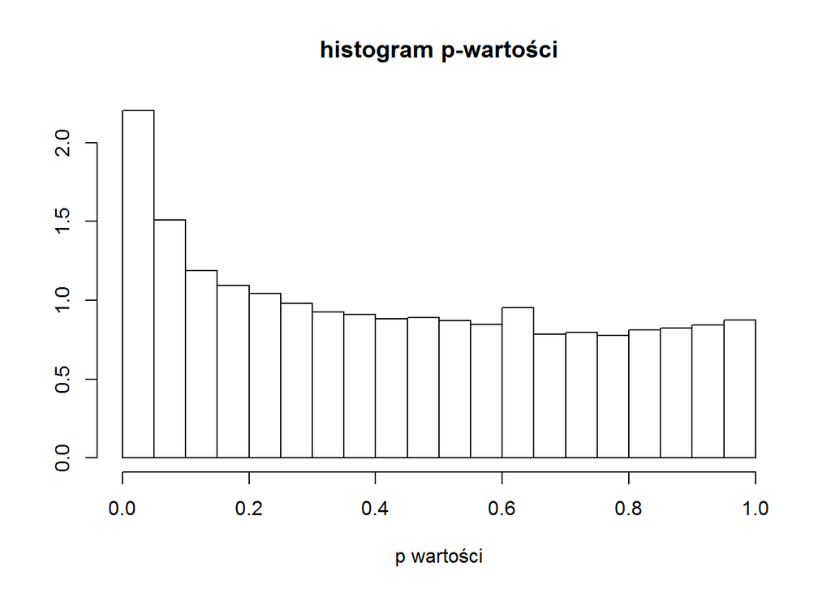

Histogram p-wartosci jest zgodny z oczekiwaniami- w przypadku p-wartości powyżej ustalonego poziomu istotności ich rozkład jest zbliżony do jednostajnego. Co więcej, znowu na postawie teoretycznych obserwacji rozkład wspomnianych współczynników powienien być normalny ze średnią dla całej próby.

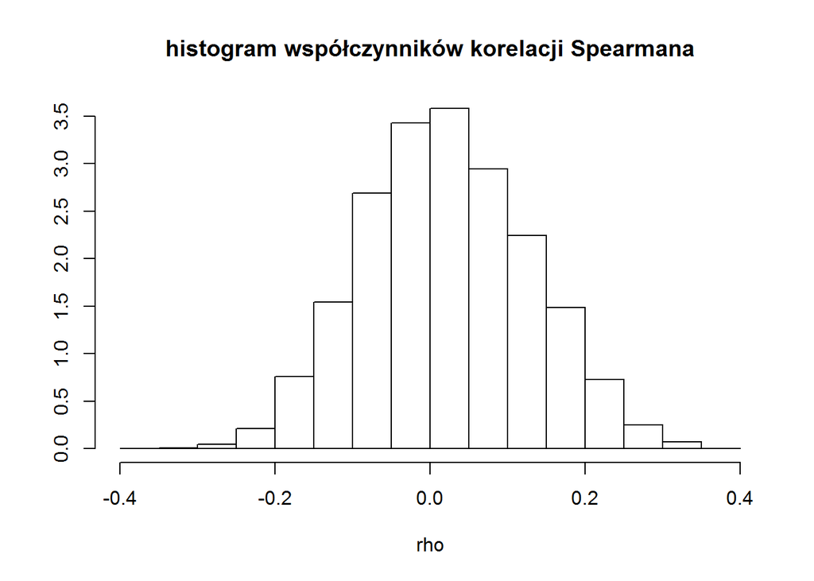

Jak widać po raz kolejny otrzymałyśmy potwierdzenie wcześniej postawionych hipotez. (Histogram potwierdza przypuszczenia odnośnie normalnego rozkładu współczynników korelacji)

Czas najwyższy ustalić poziom istotności pozwalający zweryfikować prawdziwość postawionych wcześniej hipotez. Postanowiłyśmy zbadać ilość zmiennych istotnych dla poziomu 0.05.

Ze względu na testowanie pakietu hipotez zastosujemy również korektę FDR pozwalająca zwiększyć moc przeprowadzanego testu (czyli zmniejszyć średnią ilości fałszywie odrzuconych hipotez zerowych).

Sprawdzimy charakterystyki opisujące bezwzględne wartości współczynników korelacji zmiennych uznanych za istotne.

```r
summary(abs(r[p<0.05]))
```

```
##    Min. 1st Qu.  Median    Mean 3rd Qu.    Max.
##  0.1758  0.1891  0.2084  0.2175  0.2359  0.3747
```

Widzimy, że w przypadku odrzucenia hipotezy zerowej wartości współczynników są największe co do wartości bezwzględnej. Zgodne jest to z intuicyjnym przypuszczeniem mówiącym, że im większy współczynnik korelacji tym zmienne są bardziej zależne.

Wektor wazne będzie przechowywał współczynniki korelacji dla wybranych zmiennych. Obliczając jego długość otrzymamy ilość zmiennych uznanych za istotne w pierwszej części naszych rozważań.

```r
wazne <- r[p.adjust(p, method="fdr")<0.175]
length(wazne)
```

```
## [1] 84
```

Testując całą próbkę otrzymujemy 84 zmienne istotne. Pojawia się pytanie, jak będzie się zmieniać ilość wybranych genów w zależności od podziału próbki na zbiory testowe. Zbiory testowe będziemy wybierać za pomocą pakietu `caret`.

```r
library("caret")
geny <- c()
ilosci <- c()
m <- 100

geny <- c()
for (i in 1:m){

inTrain<- createDataPartition(y=cancer$death1y,p=0.75, list=FALSE)
train <- cancer[inTrain,]
d <- as.numeric(ifelse(train$death1y=='dead',1,0))

p<-apply(data.matrix(train[,-c(1,2,4)]),2,function(x)cor.test(d,x,method="spearman")$p.value)

r<-apply(data.matrix(train[,-c(1,2,4)]),2,function(x)cor.test(d,x,method="spearman")$estimate)

wazne <- r[p.adjust(p, method="fdr")<0.2]

ilosci <- c(ilosci,length(wazne))
geny <- c(geny,names(wazne))

if(chisq.test(train$Cluster,train$death1y)$p.value>0.05){
  geny <- c(geny,"Cluster")
  ilosci[i] <-ilosci[i]+1
}

}

geny <- as.factor(geny)
ile <- summary(geny)
ile[ile>=0.3*m]
```

```
## Cluster SLC17A9   PLAUR  LRRC61  CLEC5A TBL1XR1 BHLHE40    CTSB    LSP1
##     100      44      41      39      38      38      37      37      37
##    NRG1    AQP9  CSNK1D     HK3  ACTR3C SLC11A1  TM7SF4    CTF1   GPNMB
##      37      36      36      36      34      34      33      32      32
##    MLPH    STC1 C8orf58  CPPED1    CTSD  MAP2K3    NCF2 TNFSF14 ZC3H12A
##      32      32      31      31      31      31      31      31      31
##  LILRB3  SLC6A6 (Other)
##      30      30   13547
```

Podsumowując nasze działania w pierwszym etapie, zdecydowałyśmy się na badanie zależności między zmiennymi objaśniającymi oraz zmienną objaśnianą przy pomocy testu korelacji Spearmana. Ze względu na testowanie „pakietu” hipotez zastosowałyśmy poprawkę p-wartości metodą fdr, które odcięłyśmy na poziomie 0.2. Co więcej, powyższą procedurę powtórzyłyśmy przy 100-krotnym losowaniu zbioru uczącego. Jako istotne uznałyśmy zmienne pojawiające się w przynajmniej 30% powtórzeń , co pozwoliło nam ograniczyć nasz model do ok. 30 zmiennych objaśniających. Ze względów ideologicznych zdecydowałyśmy się również uwzględnić zmienną „age”.